# Howard University (Washington, DC)

### General information

- Private not-for-profit, 4-year or above
- Doctoral Universities: High Research Activity
- This is a historically black college or university (HBCU)
- Undergraduate enrollment is 6,526 (includes all undergrads; some of the numbers below are based on first time, full time, degree seeking students only).
- Mission: Howard University a culturally diverse comprehensive research intensive and historically Black private university provides an educational experience of exceptional quality at the undergraduate graduate and professional levels to students of high academic standing and potential with particular emphasis upon educational opportunities for Black students. Moreover the University is dedicated to attracting and sustaining a cadre of faculty who are through their teaching research and service committed to the development of distinguished historically aware and compassionate graduates and to the discovery of solutions to human problems in the United States and throughout the world. With an abiding interest in both domestic and international affairs the University is committed to continuing to produce leaders for America and the global community.
- 36% of applicants are admitted
- 25% of admitted applicants choose to enroll
- 86% of students stay after their first year
- 65% of students graduate
- The student to all faculty ratio is 10:1
- The student to tenured or tenure-track faculty ratio is 42:1
- Students are required to be vaccinated against COVID-19
- Employees are required to be vaccinated against COVID-19
- This college is located in a large city
- The closest mass transit is a 0 minute walk away
- As of July, 2022, the state this institution is in had abortion restrictions categorized “NA” by the [Guttmacher Institute](https://states.guttmacher.org/policies/), though this may change.
- Athletic conference: Mid-Eastern Athletic Conference

# Details

## Tables

### Degrees awarded each year

| Degree | Number |
| --- | --- |
| Associate | 0 |
| Bachelor | 923 |
| Master | 235 |
| Doctor | 476 |

### Diversity among the faculty

Two things to note here are diversity overall as well as the distribution tenure, tenure track, and non tenure track faculty. There are two main tracks in academia: faculty who are given short term contracts (and often a high teaching load and lower pay) and faculty who are essentially on probation (for 3-6 years, typically) and then are given tenure or fired. For more about tenure, see [here](https://www.aaup.org/issues/tenure). Tenure is a way of protecting academic freedom (tenured faculty can be fired for misconduct or if a program is closed, but not for their research or speech); the fact that it is often more stable also helps ensure that faculty will be at an institution long term to serve as mentors, letter writers, etc. Having more non-tenure-track faculty can save money (they are often paid less, and teach more), reduce public dissent (they can be fired for taking a stand unpopular with their employer), and reduce research or other creative output, including mentoring in these areas (teaching loads are often higher, and research/creative output expectations lower, for faculty in non-tenure-track positions at large universities).

|  | Tenured (count) | Tenure-track (count) | Non-tenure-track (count) | Tenured (percent) | Tenure-track (percent) | Non-tenure-track (percent) |
| --- | --- | --- | --- | --- | --- | --- |
| Grand total men | 286 | 82 | 133 | 30.1% | 8.6% | 14% |
| Grand total women | 189 | 94 | 166 | 19.9% | 9.9% | 17.5% |
| American Indian or Alaska Native men | 0 | 1 | 0 | 0% | 0.1% | 0% |
| American Indian or Alaska Native women | 1 | 0 | 1 | 0.1% | 0% | 0.1% |
| Asian men | 46 | 18 | 15 | 4.8% | 1.9% | 1.6% |
| Asian women | 17 | 7 | 21 | 1.8% | 0.7% | 2.2% |
| Black or African American men | 176 | 46 | 85 | 18.5% | 4.8% | 8.9% |
| Black or African American women | 127 | 61 | 109 | 13.4% | 6.4% | 11.5% |
| Hispanic or Latino men | 2 | 5 | 5 | 0.2% | 0.5% | 0.5% |
| Hispanic or Latino women | 11 | 0 | 5 | 1.2% | 0% | 0.5% |
| Native Hawaiian or Other Pacific Islander men | 0 | 0 | 0 | 0% | 0% | 0% |
| Native Hawaiian or Other Pacific Islander women | 0 | 0 | 0 | 0% | 0% | 0% |
| White men | 51 | 11 | 19 | 5.4% | 1.2% | 2% |
| White women | 31 | 21 | 24 | 3.3% | 2.2% | 2.5% |
| Two or more races men | 3 | 0 | 3 | 0.3% | 0% | 0.3% |
| Two or more races women | 2 | 4 | 1 | 0.2% | 0.4% | 0.1% |
| Race/ethnicity unknown men | 8 | 1 | 5 | 0.8% | 0.1% | 0.5% |
| Race/ethnicity unknown women | 0 | 1 | 5 | 0% | 0.1% | 0.5% |
| Nonresident alien men | 0 | 0 | 1 | 0% | 0% | 0.1% |
| Nonresident alien women | 0 | 0 | 0 | 0% | 0% | 0% |

### Diversity among the students

|  | Undergrad (count) | Grad student (count) | Undergrads (percent) | Grad students (percent) |
| --- | --- | --- | --- | --- |
| Grand total men | 1797 | 874 | 28.7% | 35.1% |
| Grand total women | 4472 | 1618 | 71.3% | 64.9% |
| American Indian or Alaska Native men | 24 | 0 | 0.4% | 0% |
| American Indian or Alaska Native women | 84 | 2 | 1.3% | 0.1% |
| Asian men | 16 | 78 | 0.3% | 3.1% |
| Asian women | 50 | 107 | 0.8% | 4.3% |
| Black or African American men | 1262 | 584 | 20.1% | 23.4% |
| Black or African American women | 3279 | 1110 | 52.3% | 44.5% |
| Hispanic men | 111 | 51 | 1.8% | 2% |
| Hispanic women | 288 | 103 | 4.6% | 4.1% |
| Native Hawaiian or Other Pacific Islander men | 3 | 1 | 0% | 0% |
| Native Hawaiian or Other Pacific Islander women | 13 | 2 | 0.2% | 0.1% |
| White men | 18 | 41 | 0.3% | 1.6% |
| White women | 44 | 80 | 0.7% | 3.2% |
| Two or more races men | 56 | 21 | 0.9% | 0.8% |
| Two or more races women | 153 | 67 | 2.4% | 2.7% |
| Race/ethnicity unknown men | 148 | 11 | 2.4% | 0.4% |
| Race/ethnicity unknown women | 421 | 13 | 6.7% | 0.5% |
| Nonresident alien men | 159 | 87 | 2.5% | 3.5% |
| Nonresident alien women | 140 | 134 | 2.2% | 5.4% |

### US student origins

First time degree seeking undergrads

| State | Number of students | Fraction of student body from each state | Fraction of 18 year olds from each state enrolled here |
| --- | --- | --- | --- |
| Alabama | 12 | 1/152 | 1/5245 |
| Alaska | 0 | 0 | 0 |
| Arizona | 7 | 1/261 | 1/13961 |
| Arkansas | 2 | 1/913 | 1/19466 |
| California | 124 | 1/15 | 1/4155 |
| Colorado | 15 | 1/122 | 1/4888 |
| Connecticut | 32 | 1/57 | 1/1570 |
| Delaware | 10 | 1/183 | 1/1257 |
| Florida | 63 | 1/29 | 1/3843 |
| Georgia | 153 | 1/12 | 1/930 |
| Hawaii | 1 | 1/1826 | 1/14975 |
| Idaho | 0 | 0 | 0 |
| Illinois | 95 | 1/19 | 1/1681 |
| Indiana | 13 | 1/140 | 1/6834 |
| Iowa | 1 | 1/1826 | 1/41858 |
| Kansas | 6 | 1/304 | 1/6522 |
| Kentucky | 6 | 1/304 | 1/9506 |
| Louisiana | 42 | 1/43 | 1/1381 |
| Maine | 3 | 1/609 | 1/5350 |
| Maryland | 203 | 1/9 | 1/388 |
| Massachusetts | 37 | 1/49 | 1/2643 |
| Michigan | 56 | 1/33 | 1/2375 |
| Minnesota | 23 | 1/79 | 1/3073 |
| Mississippi | 6 | 1/304 | 1/6651 |
| Missouri | 19 | 1/96 | 1/3898 |
| Montana | 0 | 0 | 0 |
| Nebraska | 5 | 1/365 | 1/5139 |
| Nevada | 12 | 1/152 | 1/2943 |
| New Hampshire | 1 | 1/1826 | 1/17322 |
| New Jersey | 129 | 1/14 | 1/847 |
| New Mexico | 1 | 1/1826 | 1/27661 |
| New York | 254 | 1/7 | 1/965 |
| North Carolina | 59 | 1/31 | 1/2399 |
| North Dakota | 0 | 0 | 0 |
| Ohio | 37 | 1/49 | 1/4098 |
| Oklahoma | 4 | 1/456 | 1/12685 |
| Oregon | 7 | 1/261 | 1/7056 |
| Pennsylvania | 86 | 1/21 | 1/1937 |
| Rhode Island | 4 | 1/456 | 1/3961 |
| South Carolina | 28 | 1/65 | 1/2202 |
| South Dakota | 1 | 1/1826 | 1/10907 |
| Tennessee | 22 | 1/83 | 1/3807 |
| Texas | 128 | 1/14 | 1/3135 |
| Utah | 1 | 1/1826 | 1/49459 |
| Vermont | 0 | 0 | 0 |
| Virginia | 92 | 1/20 | 1/1189 |
| Washington | 13 | 1/140 | 1/6826 |
| West Virginia | 2 | 1/913 | 1/10580 |
| Wisconsin | 11 | 1/166 | 1/6833 |
| Wyoming | 0 | 0 | 0 |

### Library resources

[output not shown]

## Figures

### Student to faculty ratio compared to similar institutions:

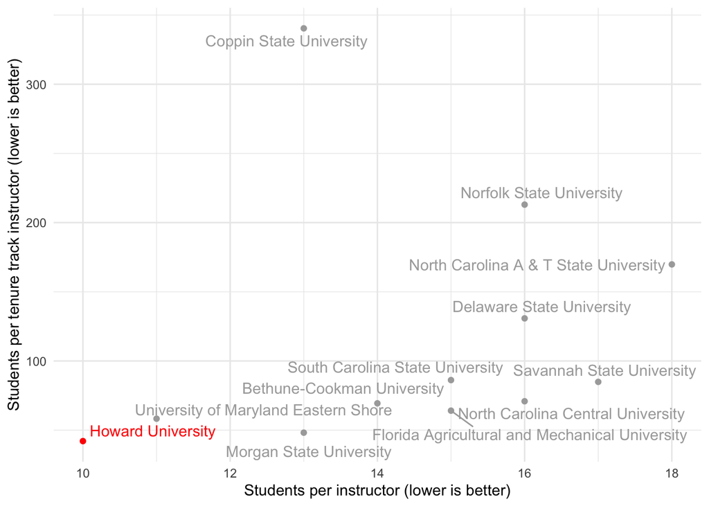

### Students from US

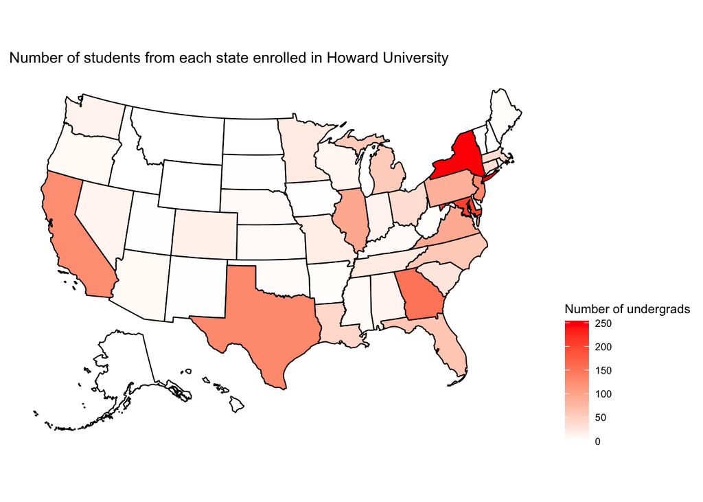

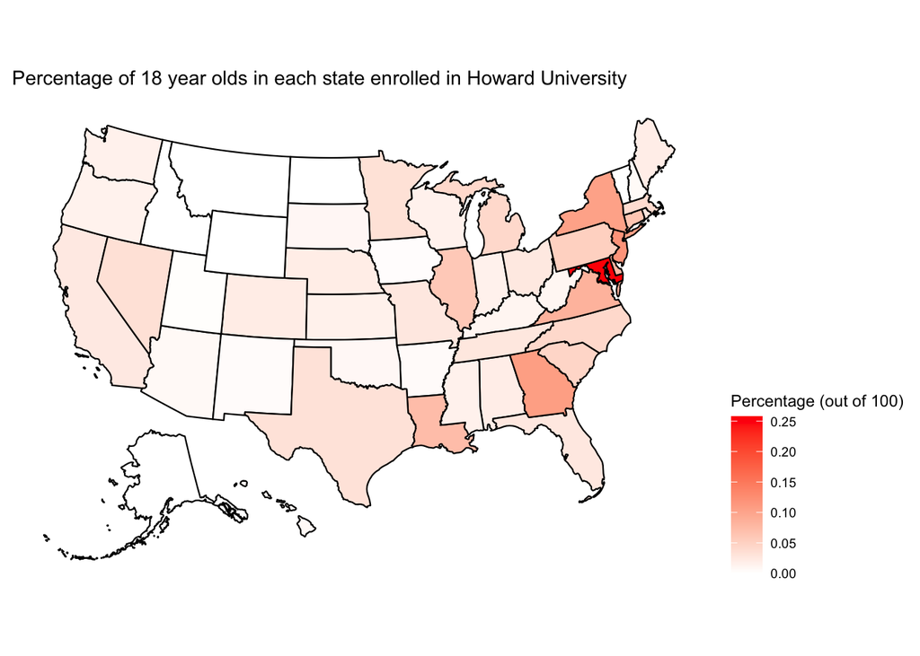